# Fraksional Faktorial 2k-p

# Menyusun Rancangan Fraksional Faktorial 2^k-p

Cara paling mudah untuk membuat rancangan faktorial 2^k−1 di R adalah menggunakan fungsi FrF2. Pada contoh berikut ini disusun rancangan 2^5−1 dengan generator 𝐸= ABCD

```r
library(FrF2)
design<-FrF2(16, 5, generators="ABCD", randomize=F)
design
```

```
##     A  B  C  D  E
## 1  -1 -1 -1 -1  1
## 2   1 -1 -1 -1 -1
## 3  -1  1 -1 -1 -1
## 4   1  1 -1 -1  1
## 5  -1 -1  1 -1 -1
## 6   1 -1  1 -1  1
## 7  -1  1  1 -1  1
## 8   1  1  1 -1 -1
## 9  -1 -1 -1  1 -1
## 10  1 -1 -1  1  1
## 11 -1  1 -1  1  1
## 12  1  1 -1  1 -1
## 13 -1 -1  1  1  1
## 14  1 -1  1  1 -1
## 15 -1  1  1  1 -1
## 16  1  1  1  1  1
## class=design, type= FrF2.generators
```

Fungsi alias dapat digunakan untuk menginformasikan struktur alias pada rancangan yang telah disusun sebelumnya. Namun fungsi ini memerlukan vektor peubah respon,𝑦, yang dapat pula dimisalkan sebagai suatu vektor peubah dari sebaran uniform

```r
library(FrF2)
y <- runif(16,0,1)
aliases(lm(y~(.)^4, data = design))
```

```
##
##  A = B:C:D:E
##  B = A:C:D:E
##  C = A:B:D:E
##  D = A:B:C:E
##  E = A:B:C:D
##  A:B = C:D:E
##  A:C = B:D:E
##  A:D = B:C:E
##  A:E = B:C:D
##  B:C = A:D:E
##  B:D = A:C:E
##  B:E = A:C:D
##  C:D = A:B:E
##  C:E = A:B:D
##  D:E = A:B:C
```

Output di atas menunjukkan bahwa pada pola alias pada rancangan 2^5−1, pengaruh utama berbaur dengan interaksi 4-faktor, dan interaksi 2-faktor berbaur dengan interaksi 3 faktor. Oleh karenanya, jika interaksi 3-faktor dan 4-faktor diasumsikan dapat diabaikan, maka pendugaan untuk semua pengaruh utama dan interaksi 2-faktor dapat dilakukan.

# Ilustrasi

Percobaan dilakukan di suatu pabrik yang membuat produk sirkuit terintegrasi. Tujuan percobaan: mengetahui pengaruh 5 buah faktor (A, B, C, D, E) dalam meningkatkan hasil produksi

```r
library(FrF2)
Data <- FrF2(16, 5, generators = "ABCD",
factor.names =list(A=c(-1,1), B=c(-1,1), C=c(-1,1), D=c(-1,1),E=c(-1,1)),
                  randomize = FALSE)
Data$y <- c(8, 9, 34, 52, 16, 22, 45, 60, 6, 10, 30, 50, 15, 21, 44, 63)
Data
```

```
##     A  B  C  D  E  y
## 1  -1 -1 -1 -1  1  8
## 2   1 -1 -1 -1 -1  9
## 3  -1  1 -1 -1 -1 34
## 4   1  1 -1 -1  1 52
## 5  -1 -1  1 -1 -1 16
## 6   1 -1  1 -1  1 22
## 7  -1  1  1 -1  1 45
## 8   1  1  1 -1 -1 60
## 9  -1 -1 -1  1 -1  6
## 10  1 -1 -1  1  1 10
## 11 -1  1 -1  1  1 30
## 12  1  1 -1  1 -1 50
## 13 -1 -1  1  1  1 15
## 14  1 -1  1  1 -1 21
## 15 -1  1  1  1 -1 44
## 16  1  1  1  1  1 63
## class=design, type= FrF2.generators
```

```r
aliases(lm( y~ (.)^4, data = Data))
```

```
##
##  A = B:C:D:E
##  B = A:C:D:E
##  C = A:B:D:E
##  D = A:B:C:E
##  E = A:B:C:D
##  A:B = C:D:E
##  A:C = B:D:E
##  A:D = B:C:E
##  A:E = B:C:D
##  B:C = A:D:E
##  B:D = A:C:E
##  B:E = A:C:D
##  C:D = A:B:E
##  C:E = A:B:D
##  D:E = A:B:C
```

```r
library(DoE.base)
model <- lm(y ~ (.)^2, data = Data)
effect <- 2 * coef(model)[-1]
result <- data.frame(
  Faktor = names(effect),
  Effect = as.vector(effect)
)
print(result)
```

```
##    Faktor Effect
## 1      A1 11.125
## 2      B1 33.875
## 3      C1 10.875
## 4      D1 -0.875
## 5      E1  0.625
## 6   A1:B1  6.875
## 7   A1:C1  0.375
## 8   A1:D1  1.125
## 9   A1:E1  1.125
## 10  B1:C1  0.625
## 11  B1:D1 -0.125
## 12  B1:E1 -0.125
## 13  C1:D1  0.875
## 14  C1:E1  0.375
## 15  D1:E1 -1.375
```

```r
library(DoE.base)
mod1 <- lm( y ~ (.)^2, data = Data)
summary(mod1)
```

```
##
## Call:
## lm.default(formula = y ~ (.)^2, data = Data)
##
## Residuals:
## ALL 16 residuals are 0: no residual degrees of freedom!
##
## Coefficients:
##             Estimate Std. Error t value Pr(>|t|)
## (Intercept)  30.3125        NaN     NaN      NaN
## A1            5.5625        NaN     NaN      NaN
## B1           16.9375        NaN     NaN      NaN
## C1            5.4375        NaN     NaN      NaN
## D1           -0.4375        NaN     NaN      NaN
## E1            0.3125        NaN     NaN      NaN
## A1:B1         3.4375        NaN     NaN      NaN
## A1:C1         0.1875        NaN     NaN      NaN
## A1:D1         0.5625        NaN     NaN      NaN
## A1:E1         0.5625        NaN     NaN      NaN
## B1:C1         0.3125        NaN     NaN      NaN
## B1:D1        -0.0625        NaN     NaN      NaN
## B1:E1        -0.0625        NaN     NaN      NaN
## C1:D1         0.4375        NaN     NaN      NaN
## C1:E1         0.1875        NaN     NaN      NaN
## D1:E1        -0.6875        NaN     NaN      NaN
##
## Residual standard error: NaN on 0 degrees of freedom
## Multiple R-squared:      1,  Adjusted R-squared:    NaN
## F-statistic:   NaN on 15 and 0 DF,  p-value: NA
```

Formula yang digunakan pada fungsi di atas, formula=y(.)^2, menghasilkan saturated model pada pengaruh utama dan interaksi 2-faktor. Oleh karena tidak ada ulangan pada percobaan tersebut, normal probability plot dari koefisien regresi dapat digunakan sebagai alat bantu untuk menilai pengaruh yang signifikan.

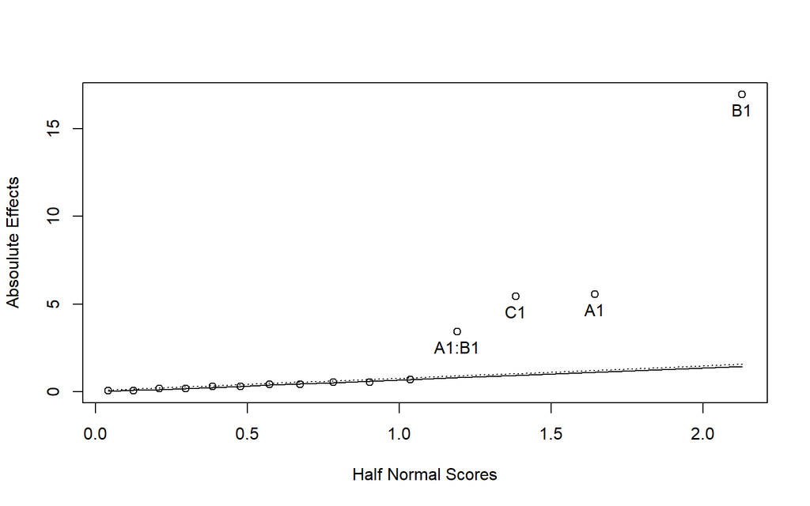

```
## Effect Report
##
## Label     Half Effect    Sig(.05)
## A1         5.5625        yes
## B1        16.9375        yes
## C1         5.4375        yes
## D1        -0.4375        no
## E1         0.3125        no
## A1:B1      3.4375        yes
## A1:C1      0.1875        no
## A1:D1      0.5625        no
## A1:E1      0.5625        no
## B1:C1      0.3125        no
## B1:D1     -0.0625        no
## B1:E1     -0.0625        no
## C1:D1      0.4375        no
## C1:E1      0.1875        no
## D1:E1     -0.6875        no
##
## Lawson, Grimshaw & Burt Rn Statistic =  6.098508
## 95th percentile of Rn =  1.201
```

```r
library(daewr)
LGB(coef(mod1)[-1], rpt = TRUE)
```

## Anova

```r
model <- aov(y~A+B+C+A:B, data = Data)
summary(model)
```

```
##             Df Sum Sq Mean Sq F value   Pr(>F)
## A            1    495     495  193.19 2.53e-08 ***
## B            1   4590    4590 1791.24 1.56e-13 ***
## C            1    473     473  184.61 3.21e-08 ***
## A:B          1    189     189   73.78 3.30e-06 ***
## Residuals   11     28       3
## ---
## Signif. codes:  0 '***' 0.001 '**' 0.01 '*' 0.05 '.' 0.1 ' ' 1
```